# act_report

Introduction

As part of the the projects in the Udacity Nano degree program where i am currently enrolled, we had to wrangle data. The Data wrangling process consisited of Data Gathering, Data Assessing, and Data Cleaning and Analysis and visualization.

We gathered data from three different sources and formats and assembled them in a single master file that was used for analysis.

We had a CSV dataset handed to us by Udacity,

Data to be downloaded programmatically using request

and Data from twitter through thier tweepy API

Gathered data was the assessed visualy and programatically for quality and tidiness.

Quality and tidiness issues identified above were cleaned with the help of pandas inbuild libraries.

Our cleaned data was then stored in a master CSV file and then, analysis performed.

Basic Statistics on the master file

Lets begin by viewing some descriptive statistics with the quantitative measures in our analysis.

Our analysis was carried by answering the following questions:

what are the top 6 popular dog names used in the tweets?

In which month and Year did the highest number of tweets occure?

Top 6 rating numbers in the dataset?

```python
master_df.describe()
```

|  | tweet_id | rate_num | rate_denom | retweet_count | favorite_count | img_num | p1_conf | p2_conf | p3_conf |
| --- | --- | --- | --- | --- | --- | --- | --- | --- | --- |
| count | 1.971000e+03 | 1971.000000 | 1971.000000 | 1971.000000 | 1971.000000 | 1971.000000 | 1971.000000 | 1.971000e+03 | 1.971000e+03 |
| mean | 7.360418e+17 | 12.223237 | 10.477423 | 2784.449518 | 8949.106545 | 1.201928 | 0.594558 | 1.345850e-01 | 6.016556e-02 |
| std | 6.752810e+16 | 41.634034 | 6.853275 | 4697.662893 | 12267.799790 | 0.559020 | 0.272126 | 1.010527e-01 | 5.094156e-02 |
| min | 6.660209e+17 | 0.000000 | 2.000000 | 16.000000 | 81.000000 | 1.000000 | 0.044333 | 1.011300e-08 | 1.740170e-10 |
| 25% | 6.758656e+17 | 10.000000 | 10.000000 | 628.500000 | 1997.000000 | 1.000000 | 0.363091 | 5.339800e-02 | 1.608055e-02 |
| 50% | 7.088343e+17 | 11.000000 | 10.000000 | 1367.000000 | 4147.000000 | 1.000000 | 0.587764 | 1.173970e-01 | 4.944380e-02 |
| 75% | 7.880951e+17 | 12.000000 | 10.000000 | 3239.000000 | 11402.500000 | 1.000000 | 0.847827 | 1.955655e-01 | 9.153815e-02 |
| max | 8.924206e+17 | 1776.000000 | 170.000000 | 79515.000000 | 132810.000000 | 4.000000 | 1.000000 | 4.880140e-01 | 2.734190e-01 |

The correlation chart is useful for finding connections between variables, especially with hypothesis testing

```python
master_df.corr()
```

|  | tweet_id | rate_num | rate_denom | retweet_count | favorite_count | img_num | p1_conf | p1_dog | p2_conf | p2_dog | p3_conf | p3_dog |
| --- | --- | --- | --- | --- | --- | --- | --- | --- | --- | --- | --- | --- |
| tweet_id | 1.000000 | 0.024917 | -0.017619 | 0.406375 | 0.655888 | 0.215396 | 0.104148 | 0.121573 | -0.001059 | 0.125866 | -0.046983 | 0.098119 |
| rate_num | 0.024917 | 1.000000 | 0.185722 | 0.014664 | 0.010876 | -0.003137 | -0.006962 | -0.030783 | -0.019657 | -0.036142 | -0.004241 | -0.030868 |
| rate_denom | -0.017619 | 0.185722 | 1.000000 | -0.018270 | -0.025708 | -0.016962 | 0.008023 | -0.004820 | -0.031914 | -0.006093 | 0.006861 | -0.000530 |
| retweet_count | 0.406375 | 0.014664 | -0.018270 | 1.000000 | 0.913014 | 0.108322 | 0.053674 | 0.006693 | -0.018573 | 0.015231 | -0.043431 | 0.009329 |
| favorite_count | 0.655888 | 0.010876 | -0.025708 | 0.913014 | 1.000000 | 0.138330 | 0.078291 | 0.053040 | -0.021465 | 0.059847 | -0.052545 | 0.040529 |
| img_num | 0.215396 | -0.003137 | -0.016962 | 0.108322 | 0.138330 | 1.000000 | 0.202765 | 0.032335 | -0.156895 | 0.056981 | -0.137720 | 0.059112 |
| p1_conf | 0.104148 | -0.006962 | 0.008023 | 0.053674 | 0.078291 | 0.202765 | 1.000000 | 0.127782 | -0.510649 | 0.143939 | -0.707916 | 0.119669 |
| p1_dog | 0.121573 | -0.030783 | -0.004820 | 0.006693 | 0.053040 | 0.032335 | 0.127782 | 1.000000 | 0.110050 | 0.639529 | 0.048624 | 0.561321 |
| p2_conf | -0.001059 | -0.019657 | -0.031914 | -0.018573 | -0.021465 | -0.156895 | -0.510649 | 0.110050 | 1.000000 | 0.096359 | 0.480698 | 0.064274 |
| p2_dog | 0.125866 | -0.036142 | -0.006093 | 0.015231 | 0.059847 | 0.056981 | 0.143939 | 0.639529 | 0.096359 | 1.000000 | 0.031648 | 0.558876 |
| p3_conf | -0.046983 | -0.004241 | 0.006861 | -0.043431 | -0.052545 | -0.137720 | -0.707916 | 0.048624 | 0.480698 | 0.031648 | 1.000000 | 0.034148 |
| p3_dog | 0.098119 | -0.030868 | -0.000530 | 0.009329 | 0.040529 | 0.059112 | 0.119669 | 0.561321 | 0.064274 | 0.558876 | 0.034148 | 1.000000 |

[figure not shown]

```python
#sb.pairplot(master_df, vars=["rate_num", "rate_denom", "retweet_count", "favorite_count", "p1_conf", "p2_conf", "p3_conf"]);
```

In our analysis, we had to ask questions like:

Question 1: What are the most common dog namess used?

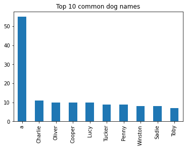

```python
import seaborn as sb
top_dogs_name=master_df.name.value_counts()[1:11]
top_dogs_name.plot(kind='bar');
plt.title('Top 10 common dog names');
plt.show()
```

The top common dog names used in the tweet archives are: Charlie, Oliver, Copper, Lucy, Tucker, Penny as shown in the visualization above.

Question 2: In which Month and Year did the highest number of tweets occurs?

```python
master_df.timestamp = pd.to_datetime(master_df.timestamp)
```

```python
master_df = master_df.set_index('timestamp')
```

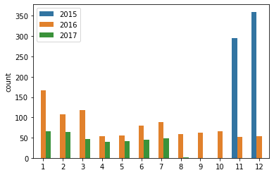

```python
tweets_per_month=master_df.groupby([master_df.index.year.values,master_df.index.month.values]).sum()
sb.countplot(data= tweets_per_month, hue= master_df.index.year.values, x =master_df.index.month.values);
```

[figure not shown]

```python
tweets_per_month.plot(figsize=(14, 8), title='New tweets over time')
plt.ylabel('Number of tweets created')
plt.show()
```

From the graphs above, we can see that, the highest number of tweets per month occured in November and December 2015 with December having the highest number of tweets in that 2015.

Question 3: What are the top 6 most used rating numbers?

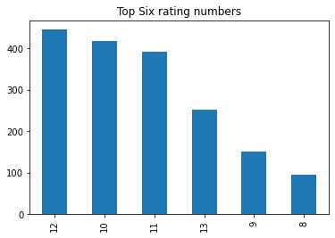

```python
master_df.rate_num.value_counts()[:6].plot(kind='bar');
plt.title('Top Six rating numbers')
plt.show()
```

From the graph above, we can see that the top 6 rating numbers are: 12, 10,11,13, 9 and 8 with rating 12 being the hghest

Conclusion:

[output not shown]

All project objectives were met though not easy